# lab8

### Lab 8. Pseudo-experiment data analysis

```python
import pickle
%matplotlib inline
import numpy as np
import matplotlib.pyplot as plt
from scipy import stats
import pandas as pd

#this sets the size of the plot to something useful
plt.rcParams["figure.figsize"] = (20,15)

highLumi = pd.read_hdf('lab7/data_highLumi_pt_250_500.h5')
lowLumi = pd.read_hdf('lab7/data_lowLumi_pt_250_500.h5')

# open the file of interest, and use pickle loading
infile = open ("lab5/qcd_100000_pt_250_500.pkl",'rb') # signal dataset
qcd = pickle.load(infile)
infile = open ("lab5/higgs_100000_pt_250_500.pkl",'rb') # background dataset
higgs = pickle.load(infile)

# list all keys of the files
print(qcd.keys())
print(higgs.keys())
```

```
Index(['pt', 'eta', 'phi', 'mass', 'ee2', 'ee3', 'd2', 'angularity', 't1',
       't2', 't3', 't21', 't32', 'KtDeltaR'],
      dtype='object')
Index(['pt', 'eta', 'phi', 'mass', 'ee2', 'ee3', 'd2', 'angularity', 't1',
       't2', 't3', 't21', 't32', 'KtDeltaR'],
      dtype='object')
```

## 1. High Luminosity Data

# Plot observed data, overlap with expected signal and background (normalized to observed yields) without event selection.

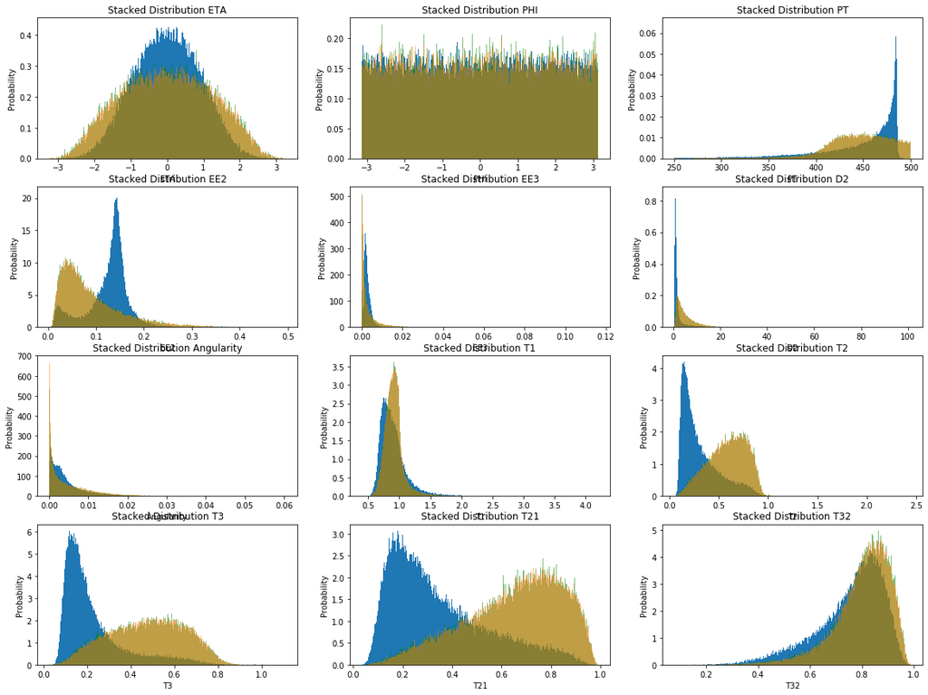

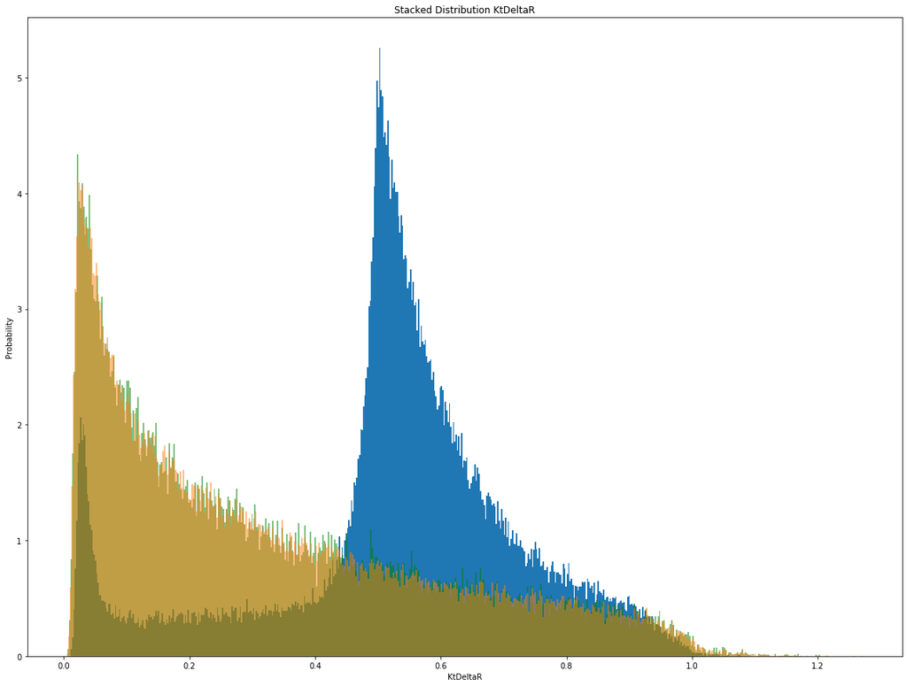

```python
plt.rcParams["figure.figsize"] = (20,15)
fig, ax = plt.subplots(4, 3)
ax[0][0].hist(higgs['eta'], 500, density=True)
ax[0][0].hist(highLumi['eta'], 500, density=True, color='green', alpha=.5)
ax[0][0].hist(qcd['eta'], 500, density=True, alpha=.5)
ax[0][0].set_title('Stacked Distribution ETA')
ax[0][0].set_ylabel('Probability')
ax[0][0].set_xlabel('ETA')
ax[0][1].hist(higgs['phi'], 500, density=True)
ax[0][1].hist(highLumi['phi'], 500, density=True, color='green', alpha=.5)
ax[0][1].hist(qcd['phi'], 500, density=True, alpha=.5)
ax[0][1].set_title('Stacked Distribution PHI')
ax[0][1].set_ylabel('Probability')
ax[0][1].set_xlabel('PHI')
ax[0][2].hist(higgs['pt'], 500, density=True)
ax[0][2].hist(highLumi['pt'], 500, density=True, color='green', alpha=.5)
ax[0][2].hist(qcd['pt'], 500, density=True, alpha=.5)
ax[0][2].set_title('Stacked Distribution PT')
ax[0][2].set_ylabel('Probability')
ax[0][2].set_xlabel('PT')

ax[1][0].hist(higgs['ee2'], 500, density=True)
ax[1][0].hist(highLumi['ee2'], 500, density=True, color='green', alpha=.5)
ax[1][0].hist(qcd['ee2'], 500, density=True, alpha=.5)
ax[1][0].set_title('Stacked Distribution EE2')
ax[1][0].set_ylabel('Probability')
ax[1][0].set_xlabel('EE2')
ax[1][1].hist(higgs['ee3'], 500, density=True)
ax[1][1].hist(highLumi['ee3'], 500, density=True, color='green', alpha=.5)
ax[1][1].hist(qcd['ee3'], 500, density=True, alpha=.5)
ax[1][1].set_title('Stacked Distribution EE3')
ax[1][1].set_ylabel('Probability')
ax[1][1].set_xlabel('EE3')
ax[1][2].hist(higgs['d2'], 500, density=True)
ax[1][2].hist(highLumi['d2'], 500, density=True, color='green', alpha=.5)
ax[1][2].hist(qcd['d2'], 500, density=True, alpha=.5)
ax[1][2].set_title('Stacked Distribution D2')
ax[1][2].set_ylabel('Probability')
ax[1][2].set_xlabel('D2')

ax[2][0].hist(higgs['angularity'], 500, density=True)
ax[2][0].hist(highLumi['angularity'], 500, density=True, color='green', alpha=.5)
ax[2][0].hist(qcd['angularity'], 500, density=True, alpha=.5)
ax[2][0].set_title('Stacked Distribution Angularity')
ax[2][0].set_ylabel('Probability')
ax[2][0].set_xlabel('Angularity')
ax[2][1].hist(higgs['t1'], 500, density=True)
ax[2][1].hist(highLumi['t1'], 500, density=True, color='green', alpha=.5)
ax[2][1].hist(qcd['t1'], 500, density=True, alpha=.5)
ax[2][1].set_title('Stacked Distribution T1')
ax[2][1].set_ylabel('Probability')
ax[2][1].set_xlabel('T1')
ax[2][2].hist(higgs['t2'], 500, density=True)
ax[2][2].hist(highLumi['t2'], 500, density=True, color='green', alpha=.5)
ax[2][2].hist(qcd['t2'], 500, density=True, alpha=.5)
ax[2][2].set_title('Stacked Distribution T2')
ax[2][2].set_ylabel('Probability')
ax[2][2].set_xlabel('T2')

ax[3][0].hist(higgs['t3'], 500, density=True)
ax[3][0].hist(highLumi['t3'], 500, density=True, color='green', alpha=.5)
ax[3][0].hist(qcd['t3'], 500, density=True, alpha=.5)
ax[3][0].set_title('Stacked Distribution T3')
ax[3][0].set_ylabel('Probability')
ax[3][0].set_xlabel('T3')
ax[3][1].hist(higgs['t21'], 500, density=True)
ax[3][1].hist(highLumi['t21'], 500, density=True, color='green', alpha=.5)
ax[3][1].hist(qcd['t21'], 500, density=True, alpha=.5)
ax[3][1].set_title('Stacked Distribution T21')
ax[3][1].set_ylabel('Probability')
ax[3][1].set_xlabel('T21')
ax[3][2].hist(higgs['t32'], 500, density=True)
ax[3][2].hist(highLumi['t32'], 500, density=True, color='green', alpha=.5)
ax[3][2].hist(qcd['t32'], 500, density=True, alpha=.5)
ax[3][2].set_title('Stacked Distribution T32')
ax[3][2].set_ylabel('Probability')
ax[3][2].set_xlabel('T32')
plt.show()

plt.hist(higgs['KtDeltaR'], 500, density=True)
plt.hist(highLumi['KtDeltaR'], 500, density=True, color='green', alpha=.5)
plt.hist(qcd['KtDeltaR'], 500, density=True, alpha=.5)
plt.title('Stacked Distribution KtDeltaR')
plt.ylabel('Probability')
plt.xlabel('KtDeltaR')
plt.show()
```

# Plot observed data, overlap with expected signal and background (normalized to observed yields) with optimal event selection.

```
Significance (Mass cuts 120-130):  2.4225963501794676
```

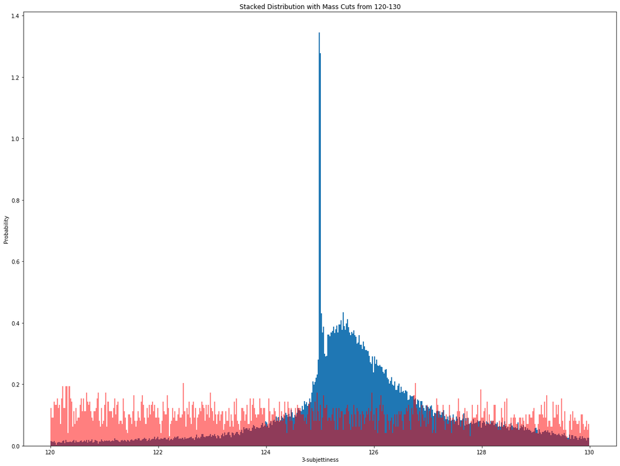

```python
origArr1 = len(qcd['mass'])
origSig1 = len(qcd['mass'])

word = 'mass'
newArr1Mass = []
newSig1Mass = []
arr1Ind = []
sig1Ind = []
for i in range(len(qcd[word])):
    if(qcd[word][i] < 130 and qcd[word][i] > 120):
        newArr1Mass.append(qcd[word][i])
        arr1Ind.append(i)
    if(higgs[word][i] < 130 and higgs[word][i] > 120):
        newSig1Mass.append(higgs[word][i])
        sig1Ind.append(i)
print('Significance (Mass cuts 120-130): ', (100 * (len(newSig1Mass) / origSig1)) / (20000 * (len(newArr1Mass) / origArr1))**.5)
plt.hist(newSig1Mass, 500, density=True)
plt.hist(newArr1Mass, 500, density=True, color='red', alpha=.5)
plt.title('Stacked Distribution with Mass Cuts from 120-130')
plt.xlabel('3-subjettiness')
plt.ylabel('Probability')
plt.show()
```

```
Significance T2 before optimization:  2.4225963501794676
Significance T2 with QCD data:  4.525187255710875
Significance T2 with high Lumi data:  1.9881665599130418
```

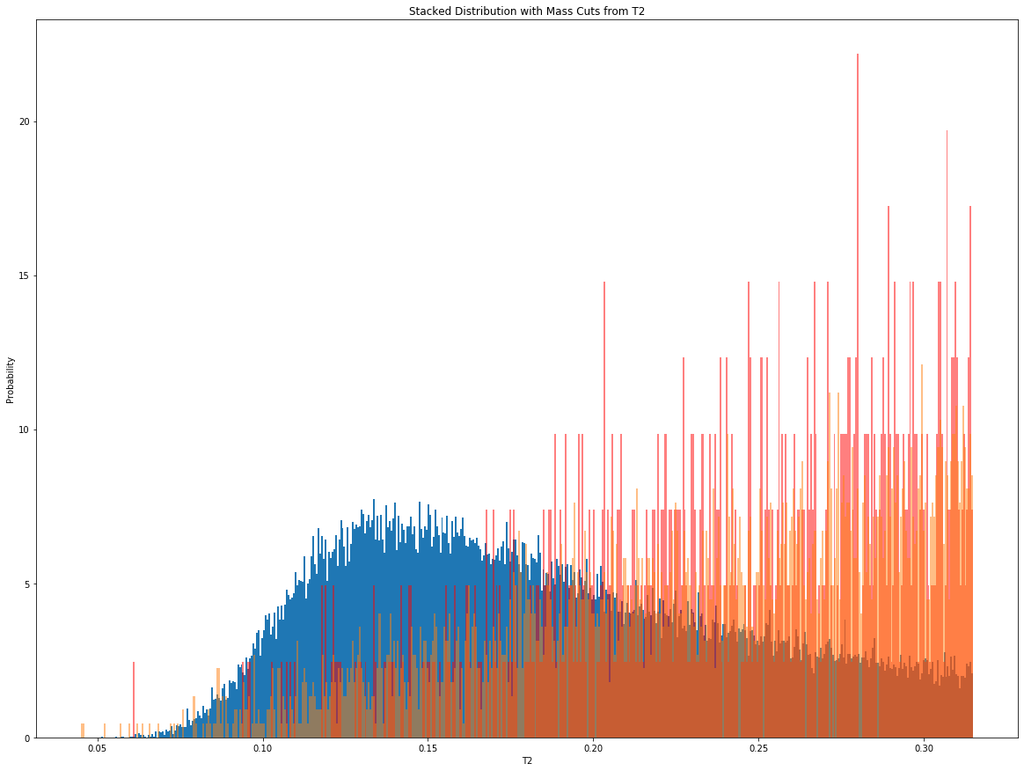

```python
arr1MassD2 = []
arr1MassSigD2 = []
for i in arr1Ind:
    arr1MassD2.append(qcd['t2'][i])
for i in sig1Ind:
    arr1MassSigD2.append(higgs['t2'][i])

print('Significance T2 before optimization: ', (100 * (len(arr1MassSigD2) / origSig1)) / (20000 * (len(arr1MassD2) / origArr1))**.5)

newArr1D2 = []
newSig1D2 = []
arr1Ind2 = []
sig1Ind2 = []
for i in range(len(arr1MassD2)):
    if(arr1MassD2[i] < .315 and arr1MassD2[i] > 0):
        newArr1D2.append(arr1MassD2[i])
        arr1Ind2.append(i)
for i in range(len(arr1MassSigD2)):
    if(arr1MassSigD2[i] < .315 and arr1MassSigD2[i] > 0):
        newSig1D2.append(arr1MassSigD2[i])
        sig1Ind2.append(i)
print('Significance T2 with QCD data: ', (100 * (len(newSig1D2) / origSig1)) / (20000 * (len(newArr1D2) / origArr1))**.5)
plt.hist(newSig1D2, 500, density=True)
plt.hist(newArr1D2, 500, density=True, color='red', alpha=.5)
plt.title('Stacked Distribution with Mass Cuts from T2')
plt.xlabel('T2')
plt.ylabel('Probability')

bottom = 0
upper = .315
observed = list(filter(lambda a: a >= bottom and a <= upper, highLumi['t2'][:]))
print('Significance T2 with high Lumi data: ', (100 * (len(newSig1D2) / origSig1)) / (20000 * (len(observed) / origArr1))**.5)
plt.hist(observed, 500, density=True, alpha=.5)
plt.show()
```

```
Significance T21 before optimization:  2.4225963501794676
Significance T21 with QCD data:  4.495255682765272
Significance T21 with high Lumi data:  2.7049427867882865
```

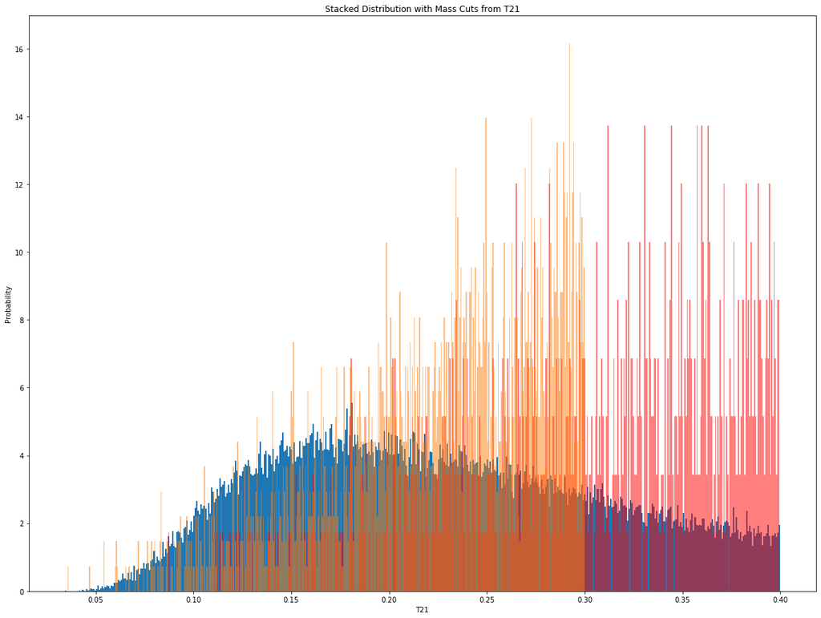

```python
arr1MassD2 = []
arr1MassSigD2 = []
for i in arr1Ind:
    arr1MassD2.append(qcd['t21'][i])
for i in sig1Ind:
    arr1MassSigD2.append(higgs['t21'][i])

print('Significance T21 before optimization: ', (100 * (len(arr1MassSigD2) / origSig1)) / (20000 * (len(arr1MassD2) / origArr1))**.5)

newArr1D2 = []
newSig1D2 = []
arr1Ind2 = []
sig1Ind2 = []
for i in range(len(arr1MassD2)):
    if(arr1MassD2[i] < .4 and arr1MassD2[i] > 0):
        newArr1D2.append(arr1MassD2[i])
        arr1Ind2.append(i)
for i in range(len(arr1MassSigD2)):
    if(arr1MassSigD2[i] < .4 and arr1MassSigD2[i] > 0):
        newSig1D2.append(arr1MassSigD2[i])
        sig1Ind2.append(i)
print('Significance T21 with QCD data: ', (100 * (len(newSig1D2) / origSig1)) / (20000 * (len(newArr1D2) / origArr1))**.5)
plt.hist(newSig1D2, 500, density=True)
plt.hist(newArr1D2, 500, density=True, color='red', alpha=.5)
plt.title('Stacked Distribution with Mass Cuts from T21')
plt.xlabel('T21')
plt.ylabel('Probability')

bottom = 0
upper = .3
observed = list(filter(lambda a: a >= bottom and a <= upper, highLumi['t21'][:]))
print('Significance T21 with high Lumi data: ', (100 * (len(newSig1D2) / origSig1)) / (20000 * (len(observed) / origArr1))**.5)
plt.hist(observed, 500, density=True, alpha=.5)
plt.show()
```

```
Significance EE2 without optimization:  2.4225963501794676
Significance of EE2 with QCD Data:  2.696050239804751
Significance EE2 with high lumi Data:  1.36016489950526
```

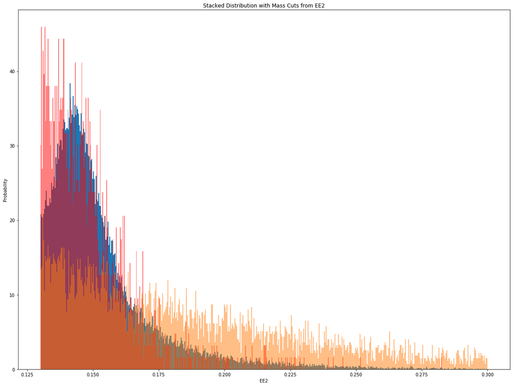

```python
arr1MassD2 = []
arr1MassSigD2 = []
for i in arr1Ind:
    arr1MassD2.append(qcd['ee2'][i])
for i in sig1Ind:
    arr1MassSigD2.append(higgs['ee2'][i])

print('Significance EE2 without optimization: ', (100 * (len(arr1MassSigD2) / origSig1)) / (20000 * (len(arr1MassD2) / origArr1))**.5)

newArr1D2 = []
newSig1D2 = []
arr1Ind2 = []
sig1Ind2 = []
for i in range(len(arr1MassD2)):
    if(arr1MassD2[i] < .3 and arr1MassD2[i] > .13):
        newArr1D2.append(arr1MassD2[i])
        arr1Ind2.append(i)
for i in range(len(arr1MassSigD2)):
    if(arr1MassSigD2[i] < .3 and arr1MassSigD2[i] > .13):
        newSig1D2.append(arr1MassSigD2[i])
        sig1Ind2.append(i)
print('Significance of EE2 with QCD Data: ', (100 * (len(newSig1D2) / origSig1)) / (20000 * (len(newArr1D2) / origArr1))**.5)
plt.hist(newSig1D2, 500, density=True)
plt.hist(newArr1D2, 500, density=True, color='red', alpha=.5)
plt.title('Stacked Distribution with Mass Cuts from EE2')
plt.xlabel('EE2')
plt.ylabel('Probability')

bottom = .13
upper = .3
observed = list(filter(lambda a: a >= bottom and a <= upper, highLumi['ee2'][:]))
print('Significance EE2 with high lumi Data: ', (100 * (len(newSig1D2) / origSig1)) / (20000 * (len(observed) / origArr1))**.5)
plt.hist(observed, 500, density=True, alpha=.5)
plt.show()
```

```
Significance T3 before optimization:  2.4225963501794676
Significance T3 with QCD data:  4.165058823529412
Significance T3 with high Lumi data:  1.833220728949757
```

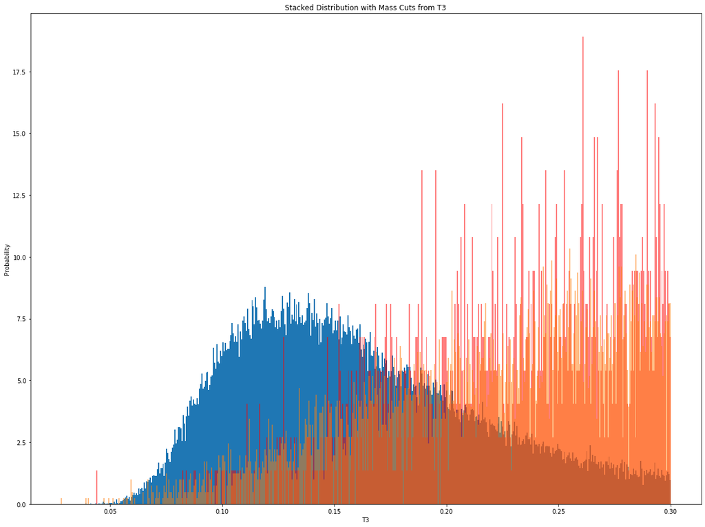

```python
arr1MassD2 = []
arr1MassSigD2 = []
for i in arr1Ind:
    arr1MassD2.append(qcd['t3'][i])
for i in sig1Ind:
    arr1MassSigD2.append(higgs['t3'][i])

print('Significance T3 before optimization: ', (100 * (len(arr1MassSigD2) / origSig1)) / (20000 * (len(arr1MassD2) / origArr1))**.5)

newArr1D2 = []
newSig1D2 = []
arr1Ind2 = []
sig1Ind2 = []
for i in range(len(arr1MassD2)):
    if(arr1MassD2[i] < .3 and arr1MassD2[i] > 0):
        newArr1D2.append(arr1MassD2[i])
        arr1Ind2.append(i)
for i in range(len(arr1MassSigD2)):
    if(arr1MassSigD2[i] < .3 and arr1MassSigD2[i] > 0):
        newSig1D2.append(arr1MassSigD2[i])
        sig1Ind2.append(i)
print('Significance T3 with QCD data: ', (100 * (len(newSig1D2) / origSig1)) / (20000 * (len(newArr1D2) / origArr1))**.5)
plt.hist(newSig1D2, 500, density=True)
plt.hist(newArr1D2, 500, density=True, color='red', alpha=.5)
plt.title('Stacked Distribution with Mass Cuts from T3')
plt.xlabel('T3')
plt.ylabel('Probability')

bottom = 0
upper = .3
observed = list(filter(lambda a: a >= bottom and a <= upper, highLumi['t3'][:]))
print('Significance T3 with high Lumi data: ', (100 * (len(newSig1D2) / origSig1)) / (20000 * (len(observed) / origArr1))**.5)
plt.hist(observed, 500, density=True, alpha=.5)
plt.show()
```

```
Significance D2:  2.4225963501794676
Significance T2:  2.4225963501794676
Significance after mass cuts D2:  2.4225963501794676
Significance after optimizing cut to D2:  3.804394193544661
D2 Significance with high Luminosity Data:  1.7084983871902997
Significance of T2 after cut is applied to T2:  3.804394193544661
Significance of T2 after optimizing cuts are applied:  4.838748789011665
T2 Significance with high Luminosity Data:  1.994284604841964
```

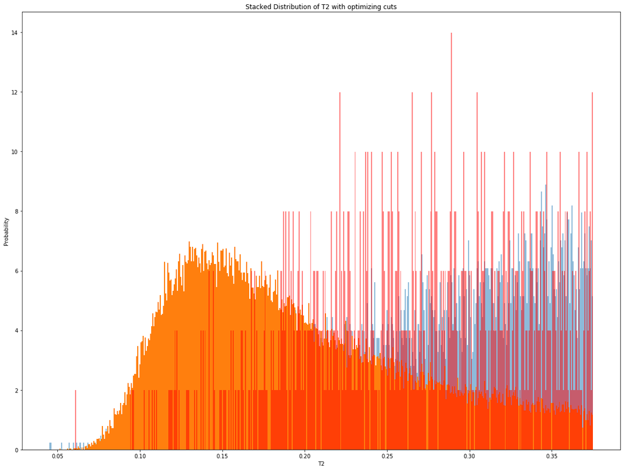

```python
origArr1 = len(qcd['mass'])
origSig1 = len(qcd['mass'])

word = 'mass'
newArr1Mass = []
newSig1Mass = []
arr1Ind = []
sig1Ind = []
for i in range(len(qcd[word])):
    if(qcd[word][i] < 130 and qcd[word][i] > 120):
        newArr1Mass.append(qcd[word][i])
        arr1Ind.append(i)
    if(higgs[word][i] < 130 and higgs[word][i] > 120):
        newSig1Mass.append(higgs[word][i])
        sig1Ind.append(i)

arr1MassD2 = []
arr1MassSigD2 = []
for i in arr1Ind:
    arr1MassD2.append(qcd['d2'][i])
for i in sig1Ind:
    arr1MassSigD2.append(higgs['d2'][i])

print('Significance D2: ', (100 * (len(arr1MassSigD2) / origSig1)) / (20000 * (len(arr1MassD2) / origArr1))**.5)


arr1MassT2 = []
arr1MassSigT2 = []
for i in arr1Ind:
    arr1MassT2.append(qcd['t2'][i])
for i in sig1Ind:
    arr1MassSigT2.append(higgs['t2'][i])

print('Significance T2: ', (100 * (len(arr1MassSigT2) / origSig1)) / (20000 * (len(arr1MassT2) / origArr1))**.5)

################################

print('Significance after mass cuts D2: ', (100 * (len(arr1MassSigD2) / origSig1)) / (20000 * (len(arr1MassD2) / origArr1))**.5)
newArr1D2 = []
newSig1D2 = []
arr1Ind = []
sig1Ind = []
for i in range(len(arr1MassD2)):
    if(arr1MassD2[i] < 2 and arr1MassD2[i] > 0):
        newArr1D2.append(arr1MassD2[i])
        arr1Ind.append(i)
for i in range(len(arr1MassSigD2)):
    if(arr1MassSigD2[i] < 2 and arr1MassSigD2[i] > 0):
        newSig1D2.append(arr1MassSigD2[i])
        sig1Ind.append(i)
print('Significance after optimizing cut to D2: ', (100 * (len(newSig1D2) / origSig1)) / (20000 * (len(newArr1D2) / origArr1))**.5)

bottom = 0
upper = 2
observed = list(filter(lambda a: a >= bottom and a <= upper, highLumi['d2'][:]))
print('D2 Significance with high Luminosity Data: ', (100 * (len(newSig1D2) / origSig1)) / (20000 * (len(observed) / origArr1))**.5)

arr1MassSecond = []
arr1MassSigSecond = []
for i in arr1Ind:
    arr1MassSecond.append(arr1MassT2[i])
for i in sig1Ind:
    arr1MassSigSecond.append(arr1MassSigT2[i])

print('Significance of T2 after cut is applied to T2: ', (100 * (len(arr1MassSigSecond) / origSig1)) / (20000 * (len(arr1MassSecond) / origArr1))**.5)


####################################

newArr1 = []
newSig1 = []
arr1Ind = []
sig1Ind = []
for i in range(len(arr1MassSecond)):
    if(arr1MassSecond[i] < .375 and arr1MassSecond[i] > 0):
        newArr1.append(arr1MassSecond[i])
        arr1Ind.append(i)
for i in range(len(arr1MassSigSecond)):
    if(arr1MassSigSecond[i] < .375 and arr1MassSigSecond[i] > 0):
        newSig1.append(arr1MassSigSecond[i])
        sig1Ind.append(i)
print('Significance of T2 after optimizing cuts are applied: ', (100 * (len(newSig1) / origSig1)) / (20000 * (len(newArr1) / origArr1))**.5)

bottom = 0
upper = .375
observed = list(filter(lambda a: a >= bottom and a <= upper, highLumi['t2'][:]))
print('T2 Significance with high Luminosity Data: ', (100 * (len(newSig1D2) / origSig1)) / (20000 * (len(observed) / origArr1))**.5)


plt.hist(observed, 500, density=True, alpha=.5)
plt.hist(newSig1, 500, density=True)
plt.hist(newArr1, 500, density=True, color='red', alpha=.5)
plt.title('Stacked Distribution of T2 with optimizing cuts')
plt.xlabel('T2')
plt.ylabel('Probability')
plt.show()
```

# Evaluate observed significance and compare your results to expectation

Change in signif. of t2:

- QCD data: 2.42 -> 4.53
- Observed Data: 2.42 -> 1.99

Change in signif. of t3

- QCD data: 2.42 -> 4.16
- Observed Data: 2.42 -> 1.83

Change in signif. of ee2

- QCD data: 2.42 -> 2.70
- Observed Data: 2.42 -> 1.36

Change in signif. of Mass cuts -> D2 -> T2

- QCD Data: 2.42 -> 3.80 -> 4.84
- Observed Data: 2.42 -> 1.71 -> 1.99

Our signficance seems to decrease drastically as we replace our QCD with Observed high luminosity data in our significance calculation. This makes sense mathemtatically because high luminosity is like a high signal source of something such as a star. With high luminosity you have a higher number of data point and so in the equation signif. = NHiggs / sqrt(NObs) as NObs increases significance decreases.

For the last plot we first applied mass cuts to both D2 and then T2 and then made further mass cuts on first D2 and then T2. Using two features to make optimizing cuts improves the significance a lot more and we can see even in this case the high luminosity data makes the signficance decrease when taking cuts at the same sections.

## 2. Low luminosity data

# Plot observed data, overlap with expected signal and background (normalized to observed yields) without event selection.

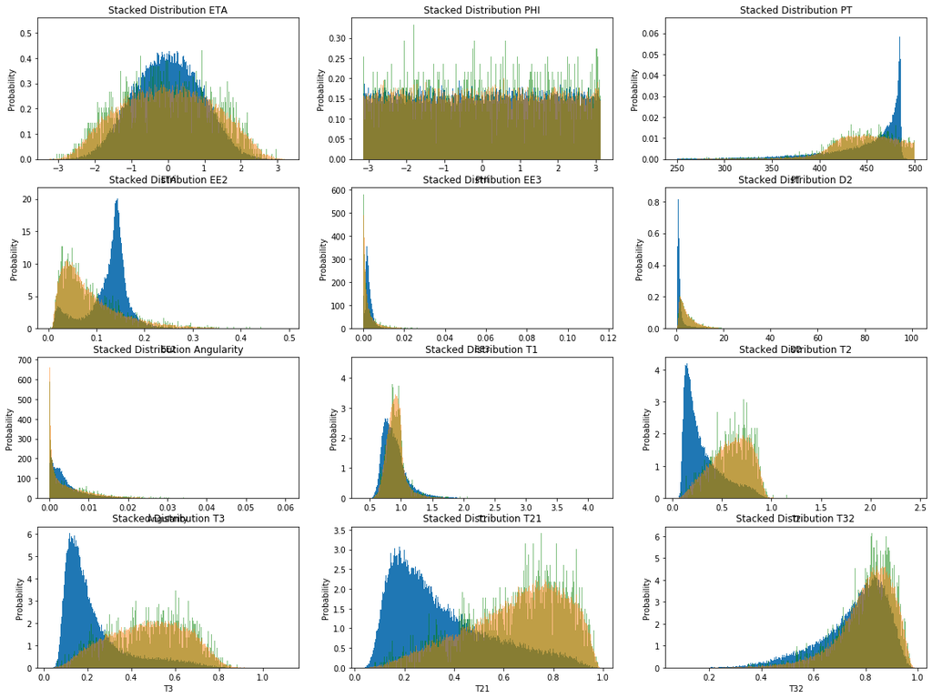

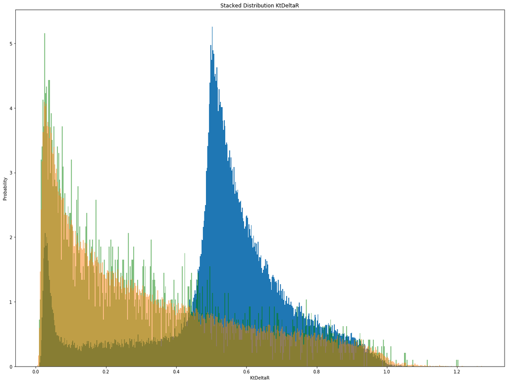

```python
plt.rcParams["figure.figsize"] = (20,15)
fig, ax = plt.subplots(4, 3)
ax[0][0].hist(higgs['eta'], 500, density=True)
ax[0][0].hist(lowLumi['eta'], 500, density=True, color='green', alpha=.5)
ax[0][0].hist(qcd['eta'], 500, density=True, alpha=.5)
ax[0][0].set_title('Stacked Distribution ETA')
ax[0][0].set_ylabel('Probability')
ax[0][0].set_xlabel('ETA')
ax[0][1].hist(higgs['phi'], 500, density=True)
ax[0][1].hist(lowLumi['phi'], 500, density=True, color='green', alpha=.5)
ax[0][1].hist(qcd['phi'], 500, density=True, alpha=.5)
ax[0][1].set_title('Stacked Distribution PHI')
ax[0][1].set_ylabel('Probability')
ax[0][1].set_xlabel('PHI')
ax[0][2].hist(higgs['pt'], 500, density=True)
ax[0][2].hist(lowLumi['pt'], 500, density=True, color='green', alpha=.5)
ax[0][2].hist(qcd['pt'], 500, density=True, alpha=.5)
ax[0][2].set_title('Stacked Distribution PT')
ax[0][2].set_ylabel('Probability')
ax[0][2].set_xlabel('PT')

ax[1][0].hist(higgs['ee2'], 500, density=True)
ax[1][0].hist(lowLumi['ee2'], 500, density=True, color='green', alpha=.5)
ax[1][0].hist(qcd['ee2'], 500, density=True, alpha=.5)
ax[1][0].set_title('Stacked Distribution EE2')
ax[1][0].set_ylabel('Probability')
ax[1][0].set_xlabel('EE2')
ax[1][1].hist(higgs['ee3'], 500, density=True)
ax[1][1].hist(lowLumi['ee3'], 500, density=True, color='green', alpha=.5)
ax[1][1].hist(qcd['ee3'], 500, density=True, alpha=.5)
ax[1][1].set_title('Stacked Distribution EE3')
ax[1][1].set_ylabel('Probability')
ax[1][1].set_xlabel('EE3')
ax[1][2].hist(higgs['d2'], 500, density=True)
ax[1][2].hist(lowLumi['d2'], 500, density=True, color='green', alpha=.5)
ax[1][2].hist(qcd['d2'], 500, density=True, alpha=.5)
ax[1][2].set_title('Stacked Distribution D2')
ax[1][2].set_ylabel('Probability')
ax[1][2].set_xlabel('D2')

ax[2][0].hist(higgs['angularity'], 500, density=True)
ax[2][0].hist(lowLumi['angularity'], 500, density=True, color='green', alpha=.5)
ax[2][0].hist(qcd['angularity'], 500, density=True, alpha=.5)
ax[2][0].set_title('Stacked Distribution Angularity')
ax[2][0].set_ylabel('Probability')
ax[2][0].set_xlabel('Angularity')
ax[2][1].hist(higgs['t1'], 500, density=True)
ax[2][1].hist(lowLumi['t1'], 500, density=True, color='green', alpha=.5)
ax[2][1].hist(qcd['t1'], 500, density=True, alpha=.5)
ax[2][1].set_title('Stacked Distribution T1')
ax[2][1].set_ylabel('Probability')
ax[2][1].set_xlabel('T1')
ax[2][2].hist(higgs['t2'], 500, density=True)
ax[2][2].hist(lowLumi['t2'], 500, density=True, color='green', alpha=.5)
ax[2][2].hist(qcd['t2'], 500, density=True, alpha=.5)
ax[2][2].set_title('Stacked Distribution T2')
ax[2][2].set_ylabel('Probability')
ax[2][2].set_xlabel('T2')

ax[3][0].hist(higgs['t3'], 500, density=True)
ax[3][0].hist(lowLumi['t3'], 500, density=True, color='green', alpha=.5)
ax[3][0].hist(qcd['t3'], 500, density=True, alpha=.5)
ax[3][0].set_title('Stacked Distribution T3')
ax[3][0].set_ylabel('Probability')
ax[3][0].set_xlabel('T3')
ax[3][1].hist(higgs['t21'], 500, density=True)
ax[3][1].hist(lowLumi['t21'], 500, density=True, color='green', alpha=.5)
ax[3][1].hist(qcd['t21'], 500, density=True, alpha=.5)
ax[3][1].set_title('Stacked Distribution T21')
ax[3][1].set_ylabel('Probability')
ax[3][1].set_xlabel('T21')
ax[3][2].hist(higgs['t32'], 500, density=True)
ax[3][2].hist(lowLumi['t32'], 500, density=True, color='green', alpha=.5)
ax[3][2].hist(qcd['t32'], 500, density=True, alpha=.5)
ax[3][2].set_title('Stacked Distribution T32')
ax[3][2].set_ylabel('Probability')
ax[3][2].set_xlabel('T32')
plt.show()

plt.hist(higgs['KtDeltaR'], 500, density=True)
plt.hist(lowLumi['KtDeltaR'], 500, density=True, color='green', alpha=.5)
plt.hist(qcd['KtDeltaR'], 500, density=True, alpha=.5)
plt.title('Stacked Distribution KtDeltaR')
plt.ylabel('Probability')
plt.xlabel('KtDeltaR')
plt.show()
```

# Plot observed data, overlap with expected signal and background (normalized to observed yields) with optimal event selection.

```
Significance (Mass cuts 120-130):  2.4225963501794676
```

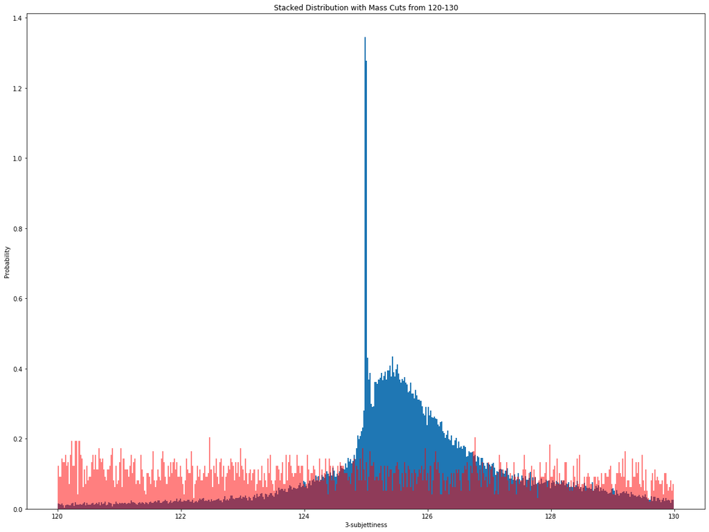

```python
origArr1 = len(qcd['mass'])
origSig1 = len(qcd['mass'])

word = 'mass'
newArr1Mass = []
newSig1Mass = []
arr1Ind = []
sig1Ind = []
for i in range(len(qcd[word])):
    if(qcd[word][i] < 130 and qcd[word][i] > 120):
        newArr1Mass.append(qcd[word][i])
        arr1Ind.append(i)
    if(higgs[word][i] < 130 and higgs[word][i] > 120):
        newSig1Mass.append(higgs[word][i])
        sig1Ind.append(i)
print('Significance (Mass cuts 120-130): ', (100 * (len(newSig1Mass) / origSig1)) / (20000 * (len(newArr1Mass) / origArr1))**.5)
plt.hist(newSig1Mass, 500, density=True)
plt.hist(newArr1Mass, 500, density=True, color='red', alpha=.5)
plt.title('Stacked Distribution with Mass Cuts from 120-130')
plt.xlabel('3-subjettiness')
plt.ylabel('Probability')
plt.show()
```

```
Significance Mass cuts 120-130:  2.4225963501794676
T2 Significance with QCD Data:  4.525187255710875
T2 Significance with Low Lumi data:  6.473001348797824
```

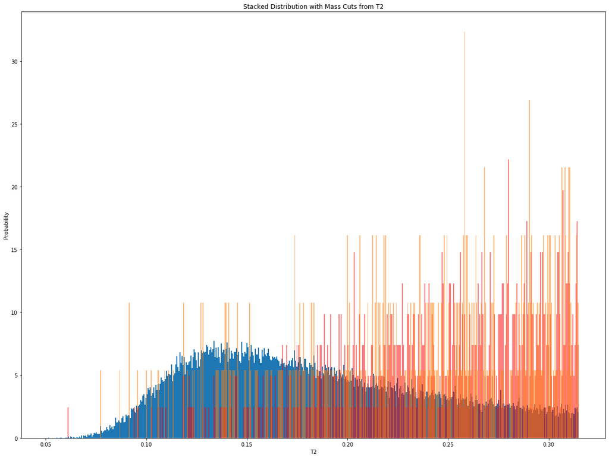

```python
arr1MassD2 = []
arr1MassSigD2 = []
for i in arr1Ind:
    arr1MassD2.append(qcd['t2'][i])
for i in sig1Ind:
    arr1MassSigD2.append(higgs['t2'][i])

print('Significance Mass cuts 120-130: ', (100 * (len(arr1MassSigD2) / origSig1)) / (20000 * (len(arr1MassD2) / origArr1))**.5)

newArr1D2 = []
newSig1D2 = []
arr1Ind2 = []
sig1Ind2 = []
for i in range(len(arr1MassD2)):
    if(arr1MassD2[i] < .315 and arr1MassD2[i] > 0):
        newArr1D2.append(arr1MassD2[i])
        arr1Ind2.append(i)
for i in range(len(arr1MassSigD2)):
    if(arr1MassSigD2[i] < .315 and arr1MassSigD2[i] > 0):
        newSig1D2.append(arr1MassSigD2[i])
        sig1Ind2.append(i)
print('T2 Significance with QCD Data: ', (100 * (len(newSig1D2) / origSig1)) / (20000 * (len(newArr1D2) / origArr1))**.5)
plt.hist(newSig1D2, 500, density=True)
plt.hist(newArr1D2, 500, density=True, color='red', alpha=.5)
plt.title('Stacked Distribution with Mass Cuts from T2')
plt.xlabel('T2')
plt.ylabel('Probability')

bottom = 0
upper = .315
observed = list(filter(lambda a: a >= bottom and a <= upper, lowLumi['t2'][:]))
print('T2 Significance with Low Lumi data: ', (100 * (len(newSig1D2) / origSig1)) / (20000 * (len(observed) / origArr1))**.5)
plt.hist(observed, 500, density=True, alpha=.5)
plt.show()
```

```
T21 Significance before optimization:  2.4225963501794676
T21 Significance with QCD data:  4.495255682765272
T21 Significance with low Lumi data:  8.679452896352396
```

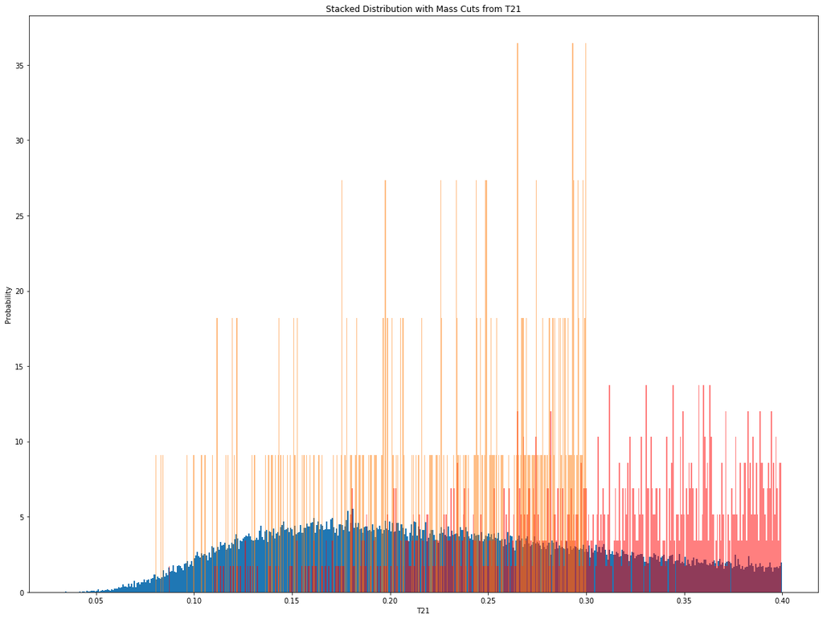

```python
arr1MassD2 = []
arr1MassSigD2 = []
for i in arr1Ind:
    arr1MassD2.append(qcd['t21'][i])
for i in sig1Ind:
    arr1MassSigD2.append(higgs['t21'][i])

print('T21 Significance before optimization: ', (100 * (len(arr1MassSigD2) / origSig1)) / (20000 * (len(arr1MassD2) / origArr1))**.5)

newArr1D2 = []
newSig1D2 = []
arr1Ind2 = []
sig1Ind2 = []
for i in range(len(arr1MassD2)):
    if(arr1MassD2[i] < .4 and arr1MassD2[i] > 0):
        newArr1D2.append(arr1MassD2[i])
        arr1Ind2.append(i)
for i in range(len(arr1MassSigD2)):
    if(arr1MassSigD2[i] < .4 and arr1MassSigD2[i] > 0):
        newSig1D2.append(arr1MassSigD2[i])
        sig1Ind2.append(i)
print('T21 Significance with QCD data: ', (100 * (len(newSig1D2) / origSig1)) / (20000 * (len(newArr1D2) / origArr1))**.5)
plt.hist(newSig1D2, 500, density=True)
plt.hist(newArr1D2, 500, density=True, color='red', alpha=.5)
plt.title('Stacked Distribution with Mass Cuts from T21')
plt.xlabel('T21')
plt.ylabel('Probability')

bottom = 0
upper = .3
observed = list(filter(lambda a: a >= bottom and a <= upper, lowLumi['t21'][:]))
print('T21 Significance with low Lumi data: ', (100 * (len(newSig1D2) / origSig1)) / (20000 * (len(observed) / origArr1))**.5)
plt.hist(observed, 500, density=True, alpha=.5)
plt.show()
```

```
EE2 Significance Before optimization:  2.4225963501794676
EE2 Significance with QCD data:  2.696050239804751
EE2 Significance with low Lumi data:  4.29989623433825
```

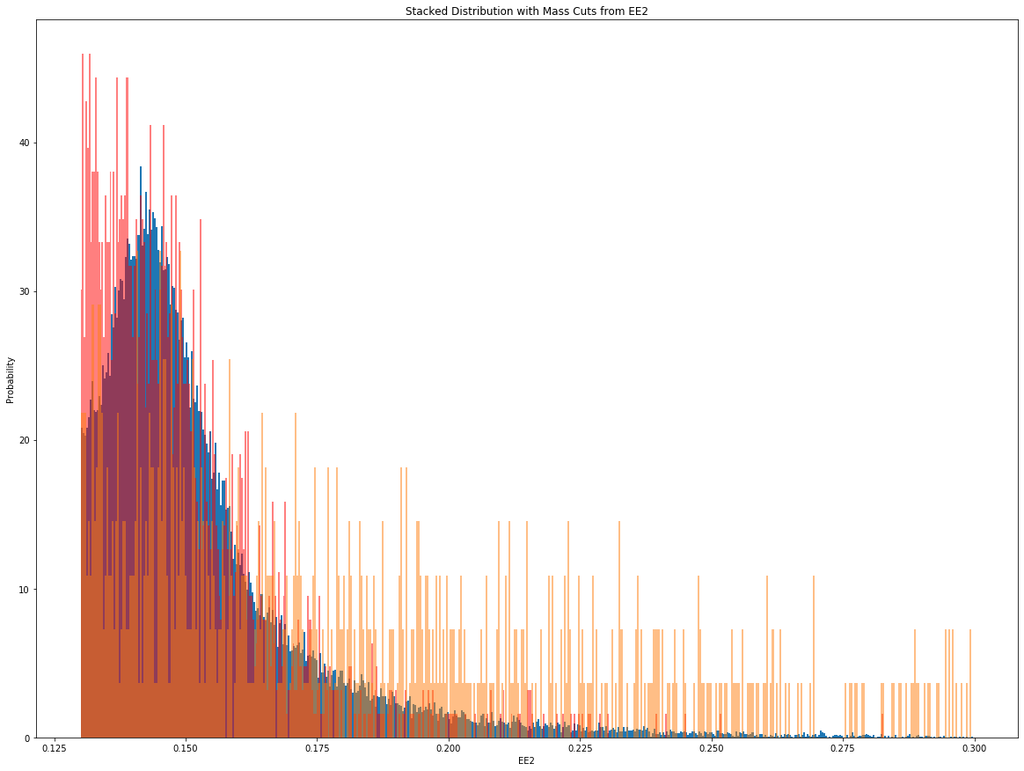

```python
arr1MassD2 = []
arr1MassSigD2 = []
for i in arr1Ind:
    arr1MassD2.append(qcd['ee2'][i])
for i in sig1Ind:
    arr1MassSigD2.append(higgs['ee2'][i])

print('EE2 Significance Before optimization: ', (100 * (len(arr1MassSigD2) / origSig1)) / (20000 * (len(arr1MassD2) / origArr1))**.5)

newArr1D2 = []
newSig1D2 = []
arr1Ind2 = []
sig1Ind2 = []
for i in range(len(arr1MassD2)):
    if(arr1MassD2[i] < .3 and arr1MassD2[i] > .13):
        newArr1D2.append(arr1MassD2[i])
        arr1Ind2.append(i)
for i in range(len(arr1MassSigD2)):
    if(arr1MassSigD2[i] < .3 and arr1MassSigD2[i] > .13):
        newSig1D2.append(arr1MassSigD2[i])
        sig1Ind2.append(i)
print('EE2 Significance with QCD data: ', (100 * (len(newSig1D2) / origSig1)) / (20000 * (len(newArr1D2) / origArr1))**.5)
plt.hist(newSig1D2, 500, density=True)
plt.hist(newArr1D2, 500, density=True, color='red', alpha=.5)
plt.title('Stacked Distribution with Mass Cuts from EE2')
plt.xlabel('EE2')
plt.ylabel('Probability')

bottom = .13
upper = .3
observed = list(filter(lambda a: a >= bottom and a <= upper, lowLumi['ee2'][:]))
print('EE2 Significance with low Lumi data: ', (100 * (len(newSig1D2) / origSig1)) / (20000 * (len(observed) / origArr1))**.5)
plt.hist(observed, 500, density=True, alpha=.5)
plt.show()
```

```
T3 Significance Before optimization  2.4225963501794676
T3 Significance with QCD Data:  4.165058823529412
T3 Significance with low Luminosity Data:  5.904601842692124
```

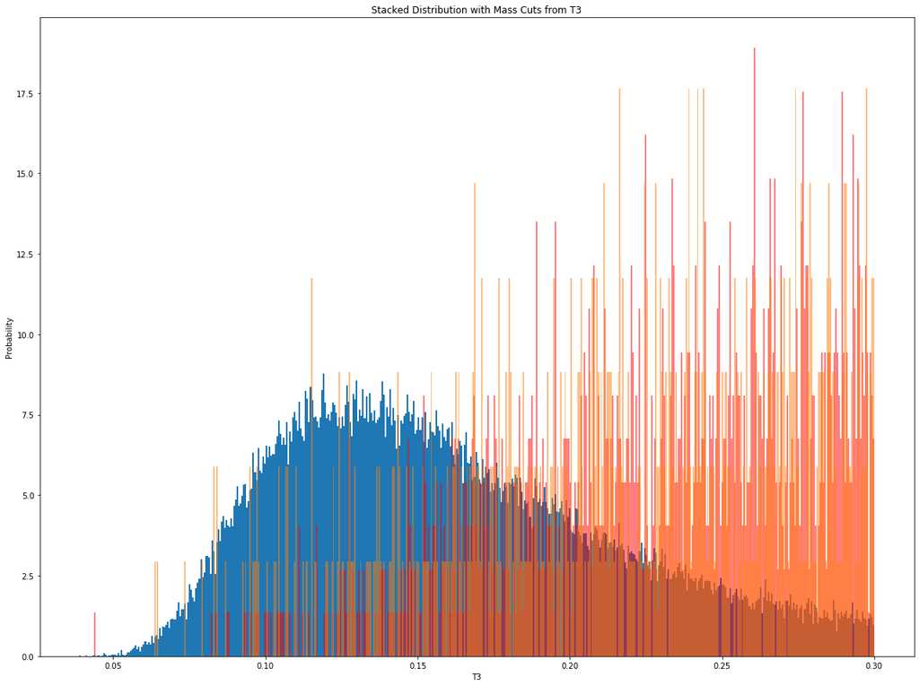

```python
arr1MassD2 = []
arr1MassSigD2 = []
for i in arr1Ind:
    arr1MassD2.append(qcd['t3'][i])
for i in sig1Ind:
    arr1MassSigD2.append(higgs['t3'][i])
print('T3 Significance Before optimization ', (100 * (len(arr1MassSigD2) / origSig1)) / (20000 * (len(arr1MassD2) / origArr1))**.5)

newArr1D2 = []
newSig1D2 = []
arr1Ind2 = []
sig1Ind2 = []
for i in range(len(arr1MassD2)):
    if(arr1MassD2[i] < .3 and arr1MassD2[i] > 0):
        newArr1D2.append(arr1MassD2[i])
        arr1Ind2.append(i)
for i in range(len(arr1MassSigD2)):
    if(arr1MassSigD2[i] < .3 and arr1MassSigD2[i] > 0):
        newSig1D2.append(arr1MassSigD2[i])
        sig1Ind2.append(i)
print('T3 Significance with QCD Data: ', (100 * (len(newSig1D2) / origSig1)) / (20000 * (len(newArr1D2) / origArr1))**.5)
plt.hist(newSig1D2, 500, density=True)
plt.hist(newArr1D2, 500, density=True, color='red', alpha=.5)
plt.title('Stacked Distribution with Mass Cuts from T3')
plt.xlabel('T3')
plt.ylabel('Probability')

bottom = 0
upper = .3
observed = list(filter(lambda a: a >= bottom and a <= upper, lowLumi['t3'][:]))
print('T3 Significance with low Luminosity Data: ', (100 * (len(newSig1D2) / origSig1)) / (20000 * (len(observed) / origArr1))**.5)
plt.hist(observed, 500, density=True, alpha=.5)
plt.show()
```

```
Significance D2:  2.4225963501794676
Significance T2:  2.4225963501794676
Significance after mass cuts D2:  2.4225963501794676
Significance after optimizing cut to D2:  3.804394193544661
D2 Significance with low Luminosity Data:  5.465373557813786
Significance of T2 after cut is applied to T2:  3.804394193544661
Significance of T2 after optimizing cuts are applied:  4.838748789011665
T2 Significance with low Luminosity Data:  6.449531373315401
```

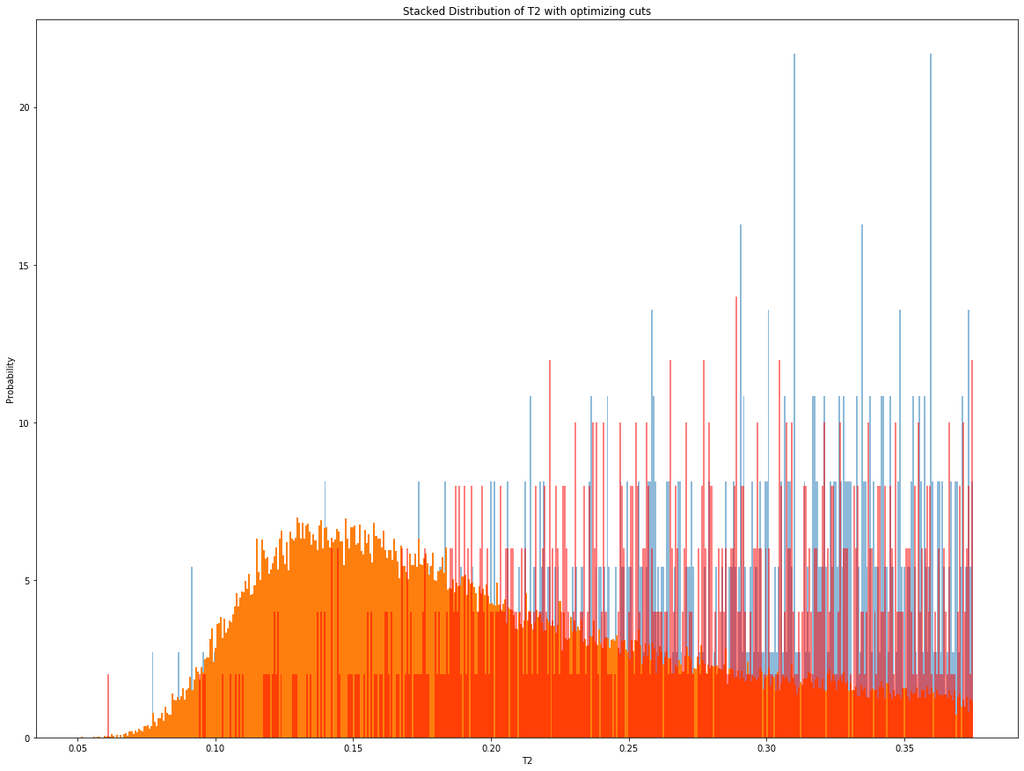

```python
origArr1 = len(qcd['mass'])
origSig1 = len(qcd['mass'])

word = 'mass'
newArr1Mass = []
newSig1Mass = []
arr1Ind = []
sig1Ind = []
for i in range(len(qcd[word])):
    if(qcd[word][i] < 130 and qcd[word][i] > 120):
        newArr1Mass.append(qcd[word][i])
        arr1Ind.append(i)
    if(higgs[word][i] < 130 and higgs[word][i] > 120):
        newSig1Mass.append(higgs[word][i])
        sig1Ind.append(i)

arr1MassD2 = []
arr1MassSigD2 = []
for i in arr1Ind:
    arr1MassD2.append(qcd['d2'][i])
for i in sig1Ind:
    arr1MassSigD2.append(higgs['d2'][i])

print('Significance D2: ', (100 * (len(arr1MassSigD2) / origSig1)) / (20000 * (len(arr1MassD2) / origArr1))**.5)

arr1MassT2 = []
arr1MassSigT2 = []
for i in arr1Ind:
    arr1MassT2.append(qcd['t2'][i])
for i in sig1Ind:
    arr1MassSigT2.append(higgs['t2'][i])

print('Significance T2: ', (100 * (len(arr1MassSigT2) / origSig1)) / (20000 * (len(arr1MassT2) / origArr1))**.5)

################################

print('Significance after mass cuts D2: ', (100 * (len(arr1MassSigD2) / origSig1)) / (20000 * (len(arr1MassD2) / origArr1))**.5)
newArr1D2 = []
newSig1D2 = []
arr1Ind = []
sig1Ind = []
for i in range(len(arr1MassD2)):
    if(arr1MassD2[i] < 2 and arr1MassD2[i] > 0):
        newArr1D2.append(arr1MassD2[i])
        arr1Ind.append(i)
for i in range(len(arr1MassSigD2)):
    if(arr1MassSigD2[i] < 2 and arr1MassSigD2[i] > 0):
        newSig1D2.append(arr1MassSigD2[i])
        sig1Ind.append(i)
print('Significance after optimizing cut to D2: ', (100 * (len(newSig1D2) / origSig1)) / (20000 * (len(newArr1D2) / origArr1))**.5)

bottom = 0
upper = 2
observed = list(filter(lambda a: a >= bottom and a <= upper, lowLumi['d2'][:]))
print('D2 Significance with low Luminosity Data: ', (100 * (len(newSig1D2) / origSig1)) / (20000 * (len(observed) / origArr1))**.5)

arr1MassSecond = []
arr1MassSigSecond = []
for i in arr1Ind:
    arr1MassSecond.append(arr1MassT2[i])
for i in sig1Ind:
    arr1MassSigSecond.append(arr1MassSigT2[i])

print('Significance of T2 after cut is applied to T2: ', (100 * (len(arr1MassSigSecond) / origSig1)) / (20000 * (len(arr1MassSecond) / origArr1))**.5)

####################################

newArr1 = []
newSig1 = []
arr1Ind = []
sig1Ind = []
for i in range(len(arr1MassSecond)):
    if(arr1MassSecond[i] < .375 and arr1MassSecond[i] > 0):
        newArr1.append(arr1MassSecond[i])
        arr1Ind.append(i)
for i in range(len(arr1MassSigSecond)):
    if(arr1MassSigSecond[i] < .375 and arr1MassSigSecond[i] > 0):
        newSig1.append(arr1MassSigSecond[i])
        sig1Ind.append(i)
print('Significance of T2 after optimizing cuts are applied: ', (100 * (len(newSig1) / origSig1)) / (20000 * (len(newArr1) / origArr1))**.5)

bottom = 0
upper = .375
observed = list(filter(lambda a: a >= bottom and a <= upper, lowLumi['t2'][:]))
print('T2 Significance with low Luminosity Data: ', (100 * (len(newSig1D2) / origSig1)) / (20000 * (len(observed) / origArr1))**.5)


plt.hist(observed, 500, density=True, alpha=.5)
plt.hist(newSig1, 500, density=True)
plt.hist(newArr1, 500, density=True, color='red', alpha=.5)
plt.title('Stacked Distribution of T2 with optimizing cuts')
plt.xlabel('T2')
plt.ylabel('Probability')
plt.show()
```

# Evaluate observed significance and compare your results to expectation

Change in signif. of t2:

- QCD data: 2.42 -> 4.53
- Observed Data: 2.42 -> 6.47

Change in signif. of t3

- QCD data: 2.42 -> 4.16
- Observed Data: 2.42 -> 5.90

Change in signif. of ee2

- QCD data: 2.42 -> 2.70
- Observed Data: 2.42 -> 4.30

Change in signif. of t21

- QCD data: 2.42 -> 4.49
- Observed Data: 2.42 -> 8.68

Change in signif. of Mass cuts -> D2 -> T2

- QCD Data: 2.42 -> 3.80 -> 4.84
- Observed Data: 2.42 -> 5.46 -> 6.45

Something very interesting to notice is that the significance seems to improve as we replace QCD with Observed low luminosity data in our significance calculation. This makes sense mathemtatically because low luminosity is like a low signal source of something such as a star. With low luminosity you have a lower number of data point and so in the equation signif. = NHiggs / sqrt(NObs) as NObs decreases significance increases.

For the last plot we first applied mass cuts to both D2 and then T2 and then made further mass cuts on first D2 and then T2. Using two features to make optimizing cuts improves the significance a lot more and we can see even in this case the low luminosity data makes the signficance increase when taking cuts at the same sections.

## 3. 95% Confidence Level of signal yields

# Evaluate the expected 95% confidence level upper limit

```python
sig = np.percentile(higgs[:], 95)
print('95% confidence of signal is: ', sig)
obs = np.percentile(lowLumi[:], 95)
print('95% confidence of observed is :', obs)
back = np.percentile(qcd[:], 95)
print('95% confidence of background is :', back)
```

```
95% confidence of signal is:  440.11661977740147
95% confidence of observed is : 431.0428111501751
95% confidence of background is : 430.2609424749775
```

From this we can observe that the 95% confidence interval of signal is 440.12 and is higher than the 95% confidence interval of the observed data. Another way of wording the information gathered here is that if we have an observed signal of 5sigma but it is too weak to be a detection, 95% of the time the true signal value will be 440.12 or less. The observed has a closer confidence interval to background than signal which is reversed for my partner which may imply that the upper Pt dataset is more accurate.

Below I have separated the 95% confidence intervals into their features to get a better understanding of the confidence interval.

```python
conf95 = np.percentile(higgs['mass'][:], 95)
print('95% confidence interval upper-bound of expected mass is: ', conf95)

conf95 = np.percentile(higgs['pt'][:], 95)
print('95% confidence interval upper-bound of expected pt is: ', conf95)

conf95 = np.percentile(higgs['eta'][:], 95)
print('95% confidence interval upper-bound of expected eta is: ', conf95)

conf95 = np.percentile(higgs['phi'][:], 95)
print('95% confidence interval upper-bound of expected phi is: ', conf95)

conf95 = np.percentile(higgs['ee2'][:], 95)
print('95% confidence interval upper-bound of expected ee2 is: ', conf95)

conf95 = np.percentile(higgs['ee3'][:], 95)
print('95% confidence interval upper-bound of expected ee3 is: ', conf95)

conf95 = np.percentile(higgs['d2'][:], 95)
print('95% confidence interval upper-bound of expected d2 is: ', conf95)

conf95 = np.percentile(higgs['angularity'][:], 95)
print('95% confidence interval upper-bound of expected angularity is: ', conf95)

conf95 = np.percentile(higgs['t1'][:], 95)
print('95% confidence interval upper-bound of expected t1 is: ', conf95)

conf95 = np.percentile(higgs['t2'][:], 95)
print('95% confidence interval upper-bound of expected t2 is: ', conf95)

conf95 = np.percentile(higgs['t3'][:], 95)
print('95% confidence interval upper-bound of expected t3 is: ', conf95)

conf95 = np.percentile(higgs['t21'][:], 95)
print('95% confidence interval upper-bound of expected t21 is: ', conf95)

conf95 = np.percentile(higgs['t32'][:], 95)
print('95% confidence interval upper-bound of expected t32 is: ', conf95)

conf95 = np.percentile(higgs['KtDeltaR'][:], 95)
print('95% confidence interval upper-bound of expected KtDeltaR is: ', conf95)
```

```
95% confidence interval upper-bound of expected mass is:  128.97399684144975
95% confidence interval upper-bound of expected pt is:  484.9859348850308
95% confidence interval upper-bound of expected eta is:  1.468738124311948
95% confidence interval upper-bound of expected phi is:  2.826618597115421
95% confidence interval upper-bound of expected ee2 is:  0.18175287615104638
95% confidence interval upper-bound of expected ee3 is:  0.005970475731153569
95% confidence interval upper-bound of expected d2 is:  7.514395336130525
95% confidence interval upper-bound of expected angularity is:  0.013443606449621956
95% confidence interval upper-bound of expected t1 is:  1.3031779304009063
95% confidence interval upper-bound of expected t2 is:  0.7286625184323081
95% confidence interval upper-bound of expected t3 is:  0.563534949937829
95% confidence interval upper-bound of expected t21 is:  0.7616336159111914
95% confidence interval upper-bound of expected t32 is:  0.913913837844326
95% confidence interval upper-bound of expected KtDeltaR is:  0.8504034318430522
```